# Activity 9.1

Author

Tuukka Jaakkola

Published

December 1, 2023

```python
import pandas as pd
import numpy as np
from sklearn.discriminant_analysis import LinearDiscriminantAnalysis
from sklearn.svm import SVC
from sklearn.pipeline import Pipeline
from sklearn.neighbors import KNeighborsClassifier
from sklearn.tree import DecisionTreeClassifier
from sklearn.linear_model import LogisticRegression
from sklearn.compose import make_column_selector, ColumnTransformer
from sklearn.preprocessing import StandardScaler, OneHotEncoder, PolynomialFeatures
```

## The Data

At this link, you will find a dataset containing information about heart disease patients: https://www.dropbox.com/scl/fi/0vrpdnq5asmeulc4gd50y/ha_1.csv?rlkey=ciisalceotl77ffqhqe3kujzv&dl=1

A description of the original dataset can be found here: https://archive.ics.uci.edu/dataset/45/heart+disease (However, this dataset has been cleaned and reduced, and the people have been given fictious names.)

```python
dis = pd.read_csv("https://www.dropbox.com/scl/fi/0vrpdnq5asmeulc4gd50y/ha_1.csv?rlkey=ciisalceotl77ffqhqe3kujzv&dl=1")
```

## 1. Logistic Regression

Fit a Logistic Regression using only `age` and `chol` (cholesterol) as predictors.

For a 55 year old, how high would their cholesterol need to be for the doctors to predict heart disease is present?

How high for the doctors to estimate a 90% chance that heart disease is present?

```python
X = dis[['age', 'chol']]
y = dis[['diagnosis']]

pipeline = Pipeline(
    [
     ("LR", LogisticRegression())]
)

fitted1 = pipeline.fit(X,y)

print(X.columns)

print(fitted1['LR'].coef_)

print(fitted1['LR'].intercept_)

# zi = fitted.coef_[0]*55 + fitted.coef_[1]*chol + fitted.intercept_


pi = 0.9

zi = np.log(pi/(1-pi))

chol = (zi - fitted1['LR'].coef_[0][0]*55 - fitted1['LR'].intercept_) / fitted1['LR'].coef_[0][1]

# (2.2 - 0.047*55 + 3.24) / 0.0018
print(chol)

print(zi)
```

```
Index(['age', 'chol'], dtype='object')
[[0.04686331 0.00180124]]
[-3.24011226]
[1587.71587928]
2.1972245773362196
```

## 2. Linear Discriminant Analysis

Fit an LDA model using only `age` and `chol` (cholesterol) as predictors.

For a 55 year old, how high would their cholesterol need to be for the doctors to predict heart disease is present?

```python
X = dis[['age', 'chol']]
y = dis[['diagnosis']]

pipeline = Pipeline(
    [
     ("LR", LinearDiscriminantAnalysis())]
)

fitted2 = pipeline.fit(X,y)

print(X.columns)

print(fitted2['LR'].coef_)

print(fitted2['LR'].intercept_)

pi = 0.9

zi = np.log(pi/(1-pi))

chol = (zi - fitted2['LR'].coef_[0][0]*55 - fitted2['LR'].intercept_) / fitted2['LR'].coef_[0][1]

print(chol)
```

```
Index(['age', 'chol'], dtype='object')
[[0.04655744 0.00178967]]
[-3.21967766]
[1595.9634487]
```

## 3. Support Vector Classifier

Fit an SVC model using only `age` and `chol` as predictors. Don’t forget to tune the regularization parameter.

For a 55 year old, how high would their cholesterol need to be for the doctors to predict heart disease is present?

```python
X = dis[['age', 'chol']]
y = dis[['diagnosis']]

pipeline = Pipeline(
    [
     ("LR", SVC(kernel = "linear"))]
)

fitted3 = pipeline.fit(X,y)

print(X.columns)

print(fitted3['LR'].coef_)

print(fitted3['LR'].intercept_)

pi = 0.9

zi = np.log(pi/(1-pi))

chol = (zi - fitted3['LR'].coef_[0][0]*55 - fitted3['LR'].intercept_) / fitted3['LR'].coef_[0][1]

print(chol)
```

```
Index(['age', 'chol'], dtype='object')
[[0.06439772 0.00365896]]
[-4.68603406]
[913.20548405]
```

## 4. Comparing Decision Boundaries

Make a scatterplot of `age` and `chol`, coloring the points by their true disease outcome. Add a line to the plot representing the **linear separator** (aka **decision boundary**) for each of the three models above.

```python
df1 = pd.DataFrame({'y':range(30,80), 'x1':list(map(lambda x: (0 - fitted1['LR'].coef_[0][0]*x - fitted1['LR'].intercept_) / fitted1['LR'].coef_[0][1], range(30,80)))})
df1['x1'] = df1['x1'].apply(lambda x: x[0])

df2 = pd.DataFrame({'y':range(30,80), 'x2':list(map(lambda x: (0 - fitted2['LR'].coef_[0][0]*x - fitted2['LR'].intercept_) / fitted2['LR'].coef_[0][1], range(30,80)))})
df2['x2'] = df2['x2'].apply(lambda x: x[0])

df3 = pd.DataFrame({'y':range(30,80), 'x3':list(map(lambda x: (0 - fitted3['LR'].coef_[0][0]*x - fitted3['LR'].intercept_) / fitted3['LR'].coef_[0][1], range(30,80)))})
df3['x3'] = df3['x3'].apply(lambda x: x[0])
```

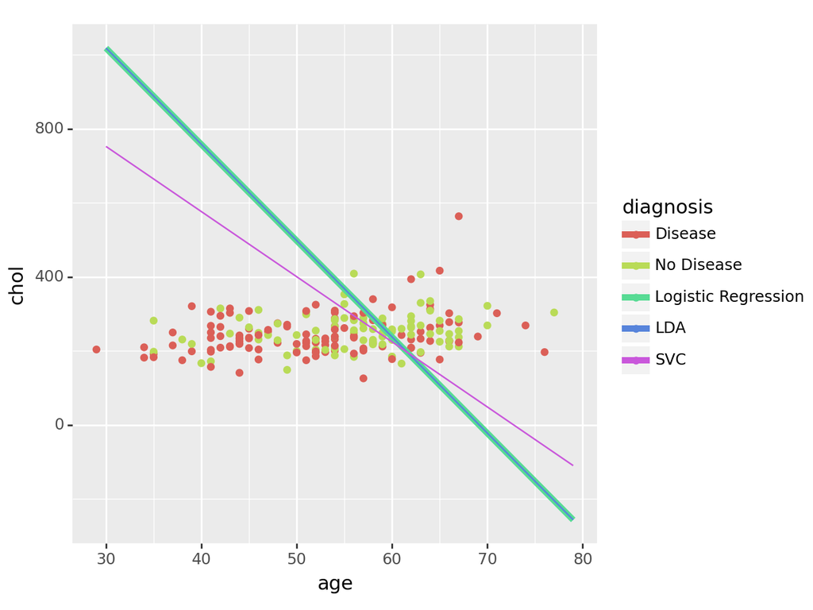

```
<Figure Size: (640 x 480)>
```

```python
from plotnine import (ggplot,
                     aes,
                     geom_point,
                    geom_line
                     )

(ggplot(dis, aes(x='age', y='chol'))
    + geom_point(aes(color='diagnosis'))
    + geom_line(aes(x='y', y = 'x1',color = '"Logistic Regression"'),size = 2, data = df1)
    + geom_line(aes(x='y', y = 'x2', color = '"LDA"'), data = df2)
    + geom_line(aes(x='y', y = 'x3', color = '"SVC"'), data = df3)
)
```